# ML_Project_2

Prateek Pagare

2025-04-26

### Predicting Cancer Diagnosis Using Support Vector Machines on National Health Interview Survey and was accessed through IPUMS Health Survey DATA set.

We first load the NHIS dataset and libraries and take a look at its structure, summary, and the first few rows.

```r
nhis_data <- read.csv("nhis_2022.csv")
str(nhis_data)
```

```
## 'data.frame':    35115 obs. of  48 variables:
##  $ YEAR       : int  2022 2022 2022 2022 2022 2022 2022 2022 2022 2022 ...
##  $ SERIAL     : int  1 2 2 3 4 4 5 6 7 8 ...
##  $ STRATA     : int  143 106 106 134 106 106 127 111 143 105 ...
##  $ PSU        : int  16 53 53 13 53 53 26 11 14 61 ...
##  $ NHISHID    : chr  "0002022H000001" "0002022H000003" "0002022H000003" "0002022H000006" ...
##  $ REGION     : int  4 3 3 2 3 3 2 4 4 1 ...
##  $ PERNUM     : int  1 1 2 1 1 2 1 1 1 1 ...
##  $ NHISPID    : chr  "0002022H00000110" "0002022H00000310" "0002022H00000320" "0002022H00000610" ...
##  $ HHX        : chr  "H000001" "H000003" "H000003" "H000006" ...
##  $ SAMPWEIGHT : num  8018 10117 7933 2681 10233 ...
##  $ ASTATFLG   : int  1 1 0 1 1 0 1 1 1 1 ...
##  $ CSTATFLG   : int  0 0 1 0 0 1 0 0 0 0 ...
##  $ AGE        : int  61 43 12 68 73 16 73 21 59 67 ...
##  $ SEX        : int  1 1 2 1 1 2 1 1 1 2 ...
```

[output cut: 34 more lines]

```r
summary(nhis_data)
```

```
##       YEAR          SERIAL          STRATA           PSU
##  Min.   :2022   Min.   :    1   Min.   :100.0   Min.   :  1.00
##  1st Qu.:2022   1st Qu.: 7184   1st Qu.:112.0   1st Qu.:  8.00
##  Median :2022   Median :14403   Median :126.0   Median : 23.00
##  Mean   :2022   Mean   :14419   Mean   :125.8   Mean   : 30.94
##  3rd Qu.:2022   3rd Qu.:21648   3rd Qu.:140.0   3rd Qu.: 48.00
##  Max.   :2022   Max.   :28854   Max.   :151.0   Max.   :153.00
##    NHISHID              REGION          PERNUM        NHISPID
##  Length:35115       Min.   :1.000   Min.   :1.000   Length:35115
##  Class :character   1st Qu.:2.000   1st Qu.:1.000   Class :character
##  Mode  :character   Median :3.000   Median :1.000   Mode  :character
##                     Mean   :2.712   Mean   :1.178
##                     3rd Qu.:4.000   3rd Qu.:1.000
##                     Max.   :4.000   Max.   :2.000
##      HHX              SAMPWEIGHT       ASTATFLG         CSTATFLG
##  Length:35115       Min.   :  740   Min.   :0.0000   Min.   :0.0000
##  Class :character   1st Qu.: 5095   1st Qu.:1.0000   1st Qu.:0.0000
##  Mode  :character   Median : 7947   Median :1.0000   Median :0.0000
##                     Mean   : 9343   Mean   :0.7874   Mean   :0.2126
##                     3rd Qu.:11777   3rd Qu.:1.0000   3rd Qu.:0.0000
##                     Max.   :43112   Max.   :1.0000   Max.   :1.0000
##       AGE             SEX           MARSTCUR          EDUC
##  Min.   :  0.0   Min.   :1.000   Min.   :0.000   Min.   :  0.0
##  1st Qu.: 23.0   1st Qu.:1.000   1st Qu.:1.000   1st Qu.:103.0
##  Median : 45.0   Median :2.000   Median :1.000   Median :301.0
##  Mean   : 45.3   Mean   :1.532   Mean   :3.349   Mean   :248.4
##  3rd Qu.: 65.0   3rd Qu.:2.000   3rd Qu.:6.000   3rd Qu.:400.0
##  Max.   :999.0   Max.   :9.000   Max.   :9.000   Max.   :999.0
##     HOURSWRK        POVERTY          HEIGHT          WEIGHT
##  Min.   : 0.00   Min.   :11.00   Min.   : 0.00   Min.   :  0.0
##  1st Qu.: 0.00   1st Qu.:24.00   1st Qu.:62.00   1st Qu.:130.0
##  Median : 0.00   Median :33.00   Median :66.00   Median :165.0
##  Mean   :17.64   Mean   :30.28   Mean   :60.72   Mean   :215.2
##  3rd Qu.:40.00   3rd Qu.:37.00   3rd Qu.:70.00   3rd Qu.:203.0
##  Max.   :99.00   Max.   :37.00   Max.   :99.00   Max.   :999.0
##     BMICALC        HINOTCOVE        CANCEREV       CHEARTDIEV
##  Min.   : 11.5   Min.   :1.000   Min.   :0.000   Min.   :0.0000
##  1st Qu.: 24.0   1st Qu.:1.000   1st Qu.:1.000   1st Qu.:1.0000
##  Median : 28.3   Median :1.000   Median :1.000   Median :1.0000
##  Mean   :215.8   Mean   :1.093   Mean   :0.892   Mean   :0.8533
```

[output cut: 29 more lines]

```
##  Max.   :999.0   Max.   :999.0   Max.   :999.0   Max.   :999.0
##    SPORDRMNO      FRTDRINKMNO      COFETEAMNO       POTATONO
##  Min.   :  0.0   Min.   :  0.0   Min.   :  0.0   Min.   :  0.0
##  1st Qu.:  0.0   1st Qu.:  0.0   1st Qu.:  0.0   1st Qu.:  1.0
##  Median :  0.0   Median :  0.0   Median :  1.0   Median :  2.0
##  Mean   :242.3   Mean   :242.5   Mean   :243.2   Mean   :245.7
##  3rd Qu.: 15.0   3rd Qu.: 10.0   3rd Qu.: 30.0   3rd Qu.: 20.0
##  Max.   :999.0   Max.   :999.0   Max.   :999.0   Max.   :999.0
##     PIZZANO         HRSLEEP           CVDSHT
##  Min.   :  0.0   Min.   : 0.000   Min.   :0.000
##  1st Qu.:  1.0   1st Qu.: 5.000   1st Qu.:1.000
##  Median :  2.0   Median : 7.000   Median :2.000
##  Mean   :244.8   Mean   : 8.135   Mean   :1.791
##  3rd Qu.: 10.0   3rd Qu.: 8.000   3rd Qu.:2.000
##  Max.   :999.0   Max.   :99.000   Max.   :9.000
```

```r
head(nhis_data)
```

```
##   YEAR SERIAL STRATA PSU        NHISHID REGION PERNUM          NHISPID     HHX
## 1 2022      1    143  16 0002022H000001      4      1 0002022H00000110 H000001
## 2 2022      2    106  53 0002022H000003      3      1 0002022H00000310 H000003
## 3 2022      2    106  53 0002022H000003      3      2 0002022H00000320 H000003
## 4 2022      3    134  13 0002022H000006      2      1 0002022H00000610 H000006
## 5 2022      4    106  53 0002022H000007      3      1 0002022H00000710 H000007
## 6 2022      4    106  53 0002022H000007      3      2 0002022H00000720 H000007
##   SAMPWEIGHT ASTATFLG CSTATFLG AGE SEX MARSTCUR EDUC HOURSWRK POVERTY HEIGHT
## 1       8018        1        0  61   1        1  201       45      34     69
## 2      10117        1        0  43   1        1  301       45      37     70
## 3       7933        0        1  12   2        0    0        0      37     60
## 4       2681        1        0  68   1        5  505        0      31     75
## 5      10233        1        0  73   1        1  201        0      32     71
## 6       7712        0        1  16   2        0    0        0      32     65
##   WEIGHT BMICALC HINOTCOVE CANCEREV CHEARTDIEV DIABETICEV HEARTATTEV STROKEV
```

[output cut: 27 more lines]

The dataset includes many health, demographic, and behavioral variables. A basic check shows everything loaded correctly, and we can proceed to data cleaning and selection.

In this project, I first carefully cleaned the NHIS dataset by removing missing or unknown values for key variables (cancer diagnosis, sex, BMI, alcohol days, age, and poverty ratio). After spending over 12–14 hours deeply exploring and analyzing the data, I realized that working with the full population introduced a lot of noise and imbalance.  
To improve model performance and uncover stronger patterns, I decided to subset the data and focus on a more meaningful group:

- Individuals older than 45 years (AGE>45)
- Those who were married (spouse present) (MARSTCUR ==1)
- People who reported drinking alcohol on more than 50 days per year (ALCDAYSYR > 50 days)

```r
# Clean and prepare data
nhis_data_clean <- nhis_data %>%
  mutate(
    CANCEREV = ifelse(CANCEREV %in% c(0, 7, 8, 9), NA, CANCEREV),
    CANCEREV = factor(CANCEREV, levels = c(1, 2), labels = c("No", "Yes")),
    SEX = ifelse(SEX %in% c(7, 8, 9), NA, SEX),
    SEX = factor(SEX, levels = c(1, 2), labels = c("Male", "Female")),
    BMICALC = ifelse(BMICALC == 996, NA, BMICALC),
    ALCDAYSYR = ifelse(ALCDAYSYR %in% c(995, 996, 997, 998, 999), NA, ALCDAYSYR),
    AGE = ifelse(AGE %in% c(997, 998, 999), NA, AGE),
    POVERTY = ifelse(POVERTY %in% c(98, 99), NA, POVERTY)
  ) %>%
  filter(!is.na(CANCEREV) & !is.na(SEX) & !is.na(BMICALC) &!is.na(ALCDAYSYR) & !is.na(AGE) & !is.na(POVERTY)) %>%
  filter(AGE > 45) %>%
  filter(MARSTCUR == 1) %>%
  filter(ALCDAYSYR > 50)
# Check the cleaned dataset
dim(nhis_data_clean)
```

```
## [1] 2741   48
```

```r
table(nhis_data_clean$CANCEREV)
```

```
##
##   No  Yes
## 2196  545
```

```r
table(nhis_data_clean$SEX)
```

```
##
##   Male Female
##   1612   1129
```

```r
summary(nhis_data_clean$BMICALC)
```

```
##    Min. 1st Qu.  Median    Mean 3rd Qu.    Max.
##    15.2    24.0    26.6    27.4    30.1    46.8
```

```r
summary(nhis_data_clean$ALCDAYSYR)
```

```
##    Min. 1st Qu.  Median    Mean 3rd Qu.    Max.
##    52.0    96.0   156.0   170.1   260.0   365.0
```

```r
summary(nhis_data_clean$AGE)
```

```
##    Min. 1st Qu.  Median    Mean 3rd Qu.    Max.
##    46.0    55.0    64.0    63.4    71.0    85.0
```

```r
summary(nhis_data_clean$POVERTY)
```

```
##    Min. 1st Qu.  Median    Mean 3rd Qu.    Max.
##   11.00   35.00   37.00   34.98   37.00   37.00
```

After cleaning and subsetting, the final dataset contains 2,741 individuals. Out of these, 545 individuals reported having been diagnosed with cancer, while 2,196 individuals did not.  
The data includes a balanced mix of males and females.

- The BMI values mostly range between 24 and 30, indicating a generally overweight group.
- Alcohol consumption is relatively high (median of 156 drinking days per year).
- Age centers around a median of 64 years, with a range from 46 to 85 years old.
- Most participants have a poverty ratio close to or above the federal threshold.

After cleaning the dataset and selecting adults over 45 years old who are married and have a history of drinking alcohol more than 50 days per year, here I explored the distribution of alcohol, age, and sex between cancer and non-cancer groups.

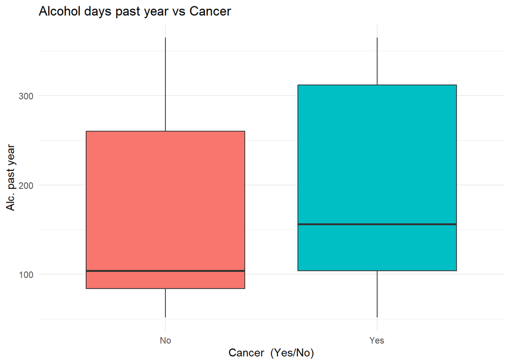

```r
# Boxplot: Frequency drank alcohol in past year vs Cancer
ggplot(nhis_data_clean, aes(x = CANCEREV, y = ALCDAYSYR, fill = CANCEREV)) +
  geom_boxplot() +
  labs(title = "Alcohol days past year vs Cancer",x = "Cancer  (Yes/No)",y = "Alc. past year") +
  theme_minimal() +theme(legend.position = "none")
```

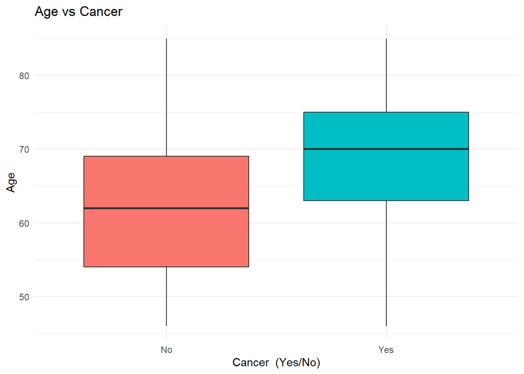

```r
# Boxplot: Age vs Cancer
ggplot(nhis_data_clean, aes(x = CANCEREV, y = AGE, fill = CANCEREV)) +
  geom_boxplot() +
  labs(title = "Age vs Cancer ",x = "Cancer  (Yes/No)",y = "Age") +
  theme_minimal() +theme(legend.position = "none")
```

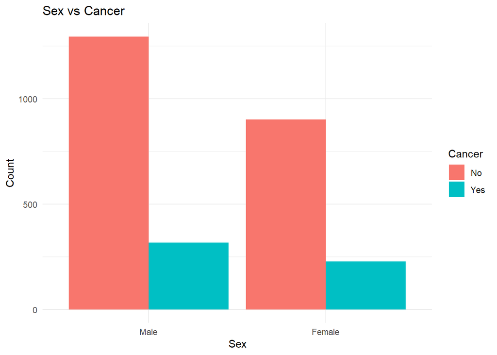

```r
# Barplot: Sex vs Cancer
ggplot(nhis_data_clean, aes(x = SEX, fill = CANCEREV)) +
  geom_bar(position = "dodge") +
  labs(title = "Sex vs Cancer ",x = "Sex", y = "Count",fill = "Cancer ") +
  theme_minimal()
```

- The first boxplot compares alcohol consumption days between people with and without cancer. The spread is wide, but individuals who had cancer seemed to show slightly higher alcohol consumption

- The second boxplot shows that people diagnosed with cancer tend to be older than those without cancer. This matches common biological understanding where cancer risk increases with age.
- The bar plot shows the counts of males and females with and without cancer, there are slightly more males than females among those diagnosed

```r
set.seed(123)

train_index <- sample(1:nrow(nhis_data_clean), 0.7 * nrow(nhis_data_clean))
nhis_train <- nhis_data_clean[train_index, ]
nhis_test <- nhis_data_clean[-train_index, ]
dim(nhis_train)
```

```
## [1] 1918   48
```

```r
dim(nhis_test)
```

```
## [1] 823  48
```

```r
table(nhis_train$CANCEREV)
```

```
##
##   No  Yes
## 1529  389
```

```r
table(nhis_test$CANCEREV)
```

```
##
##  No Yes
## 667 156
```

The training set contains 1,918 observations, and the testing set contains 823 observations. Within the training data, 1,529 people had no history of cancer and 389 had a history of cancer. The testing set has 667 people without cancer and 156 people with cancer.

## Model 1 - Linear SVM

```r
svm_linear_model <- svm(CANCEREV ~ AGE + SEX + POVERTY + BMICALC + ALCDAYSYR, data = nhis_train,kernel = "linear",cost = 10,scale = TRUE)
linear_predictions <- predict(svm_linear_model, newdata = nhis_test)
linear_conf_matrix <- table(Predicted = linear_predictions, Actual = nhis_test$CANCEREV)
linear_conf_matrix
```

```
##          Actual
## Predicted  No Yes
##       No  667 156
##       Yes   0   0
```

```r
confusionMatrix(linear_predictions, nhis_test$CANCEREV, positive = "Yes")
```

```
## Confusion Matrix and Statistics
##
##           Reference
## Prediction  No Yes
##        No  667 156
##        Yes   0   0
##
##                Accuracy : 0.8104
##                  95% CI : (0.782, 0.8367)
##     No Information Rate : 0.8104
##     P-Value [Acc > NIR] : 0.5214
##
##                   Kappa : 0
##
##  Mcnemar's Test P-Value : <2e-16
##
##             Sensitivity : 0.0000
##             Specificity : 1.0000
##          Pos Pred Value :    NaN
##          Neg Pred Value : 0.8104
##              Prevalence : 0.1896
##          Detection Rate : 0.0000
##    Detection Prevalence : 0.0000
##       Balanced Accuracy : 0.5000
##
##        'Positive' Class : Yes
##
```

```r
summary(svm_linear_model)
```

```
##
## Call:
## svm(formula = CANCEREV ~ AGE + SEX + POVERTY + BMICALC + ALCDAYSYR,
##     data = nhis_train, kernel = "linear", cost = 10, scale = TRUE)
##
##
## Parameters:
##    SVM-Type:  C-classification
##  SVM-Kernel:  linear
##        cost:  10
##
## Number of Support Vectors:  930
##
##  ( 389 541 )
##
##
## Number of Classes:  2
##
## Levels:
##  No Yes
```

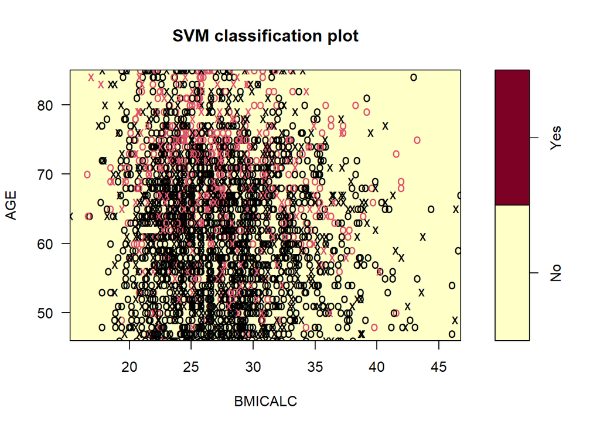

```r
plot(svm_linear_model,nhis_data_clean, AGE ~ BMICALC)
```

The model achieved about 81% accuracy on the test data,However, the confusion matrix show, predicting all individuals as “No” for cancer and never predicting “Yes” and The plot shows that there is no clear straight-line separation between cancer and non-cancer groups, which makes sense because health outcomes like cancer are influenced by many complex, overlapping factors

tune the linear model on different cost

```r
set.seed(123)
tune_linear <- tune(svm, CANCEREV ~ AGE + SEX + POVERTY + BMICALC + ALCDAYSYR, data = nhis_train,
kernel = "linear",ranges = list(cost = c(0.01, 0.1, 1, 5, 10,100)))
summary(tune_linear)
```

```
##
## Parameter tuning of 'svm':
##
## - sampling method: 10-fold cross validation
##
## - best parameters:
##  cost
##  0.01
##
## - best performance: 0.2027923
##
## - Detailed performance results:
##    cost     error dispersion
## 1 1e-02 0.2027923 0.03202164
## 2 1e-01 0.2027923 0.03202164
## 3 1e+00 0.2027923 0.03202164
## 4 5e+00 0.2027923 0.03202164
## 5 1e+01 0.2027923 0.03202164
## 6 1e+02 0.2027923 0.03202164
```

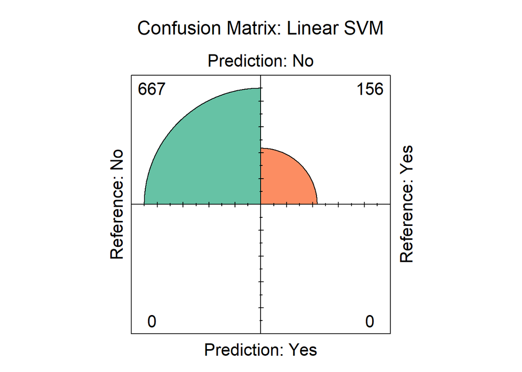

```r
best_linear_model <- tune_linear$best.model
best_pred_linear <- predict(best_linear_model, newdata = nhis_test)
a <- confusionMatrix(best_pred_linear, nhis_test$CANCEREV, positive = "Yes")
fourfoldplot(a$table, color = c("#FC8D62", "#66C2A5"),conf.level = 0, margin = 1,main = "Confusion Matrix: Linear SVM") # reference https://www.rdocumentation.org/packages/graphics/versions/3.6.2/topics/fourfoldplot
```

I performed cost parameter tuning for the linear SVM model using 10-fold cross-validation. After trying multiple values , the tuning showed that all cost values resulted in the same best performance of around 20% error . This suggests that in my subsetted dataset, adjusting the cost parameter did not lead to a significant improvement. The confusion matrix also remained the same as before tuning, indicating that the model still struggles to correctly predict positive cancer cases (predicting almost all samples as “No” for cancer).

## Model 2 - Radial SVM

so in this model I am taking only three predictors (AGE, POVERTY, and ALCDAYSYR)

```r
nhis_svm_radial <- svm(CANCEREV ~ AGE + POVERTY + ALCDAYSYR,data = nhis_train,type = "C-classification",kernel = "radial",gamma = 1,cost = 1000)
summary(nhis_svm_radial)
```

```
##
## Call:
## svm(formula = CANCEREV ~ AGE + POVERTY + ALCDAYSYR, data = nhis_train,
##     type = "C-classification", kernel = "radial", gamma = 1, cost = 1000)
##
##
## Parameters:
##    SVM-Type:  C-classification
##  SVM-Kernel:  radial
##        cost:  1000
##
## Number of Support Vectors:  940
##
##  ( 373 567 )
##
##
## Number of Classes:  2
##
## Levels:
##  No Yes
```

```r
nhis_pred_radial <- predict(nhis_svm_radial, newdata = nhis_test)
nhis_conf_matrix_radial <- confusionMatrix(nhis_pred_radial, nhis_test$CANCEREV)
nhis_conf_matrix_radial
```

```
## Confusion Matrix and Statistics
##
##           Reference
## Prediction  No Yes
##        No  629 138
##        Yes  38  18
##
##                Accuracy : 0.7861
##                  95% CI : (0.7565, 0.8137)
##     No Information Rate : 0.8104
##     P-Value [Acc > NIR] : 0.9643
##
##                   Kappa : 0.0774
##
##  Mcnemar's Test P-Value : 8.496e-14
##
##             Sensitivity : 0.9430
##             Specificity : 0.1154
##          Pos Pred Value : 0.8201
##          Neg Pred Value : 0.3214
##              Prevalence : 0.8104
##          Detection Rate : 0.7643
##    Detection Prevalence : 0.9320
##       Balanced Accuracy : 0.5292
##
##        'Positive' Class : No
##
```

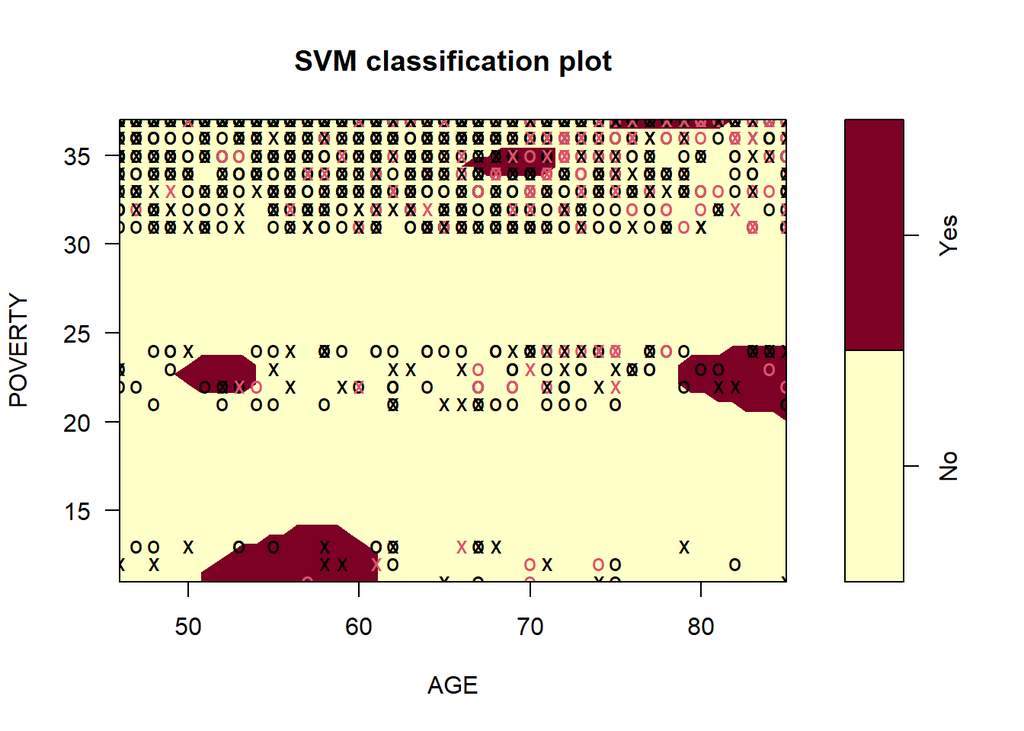

```r
plot(nhis_svm_radial,nhis_data_clean, POVERTY ~ AGE)
```

I found that reducing the number of variables made the decision boundary clearer for visualization without losing too much information. The radial model achieved an accuracy of 78.6% on the test set. From the confusion matrix, the model predicted the “No Cancer” class fairly well but struggled with detecting the “Yes Cancer” class. This can be seen by the low specificity (11.5%), meaning the model misclassifies many “Yes” cases as “No.”and plot shows non-linear separations based on AGE and POVERTY, although some overlapping still occurs.

tune of radial svm:

```r
set.seed(1235)
nhis_tune_radial <- tune(svm, CANCEREV ~ AGE + POVERTY + ALCDAYSYR,data = nhis_train,kernel = "radial",ranges = list( cost = c(0.1, 1, 10, 100, 1000),
      gamma = c(0.5, 1, 2, 3)))
summary(nhis_tune_radial)
```

```
##
## Parameter tuning of 'svm':
##
## - sampling method: 10-fold cross validation
##
## - best parameters:
##  cost gamma
##   0.1   0.5
##
## - best performance: 0.2028032
##
## - Detailed performance results:
##     cost gamma     error dispersion
## 1  1e-01   0.5 0.2028032 0.03486322
## 2  1e+00   0.5 0.2028032 0.03486322
## 3  1e+01   0.5 0.2085433 0.03562146
## 4  1e+02   0.5 0.2111502 0.03522541
## 5  1e+03   0.5 0.2194972 0.03252044
## 6  1e-01   1.0 0.2028032 0.03486322
## 7  1e+00   1.0 0.2048866 0.03393861
## 8  1e+01   1.0 0.2132390 0.03421528
## 9  1e+02   1.0 0.2174138 0.03493377
## 10 1e+03   1.0 0.2273097 0.03460421
## 11 1e-01   2.0 0.2028032 0.03486322
## 12 1e+00   2.0 0.2048920 0.03242762
## 13 1e+01   2.0 0.2184500 0.03457746
## 14 1e+02   2.0 0.2314845 0.03803535
## 15 1e+03   2.0 0.2434691 0.03049102
## 16 1e-01   3.0 0.2028032 0.03486322
## 17 1e+00   3.0 0.2101058 0.03325779
## 18 1e+01   3.0 0.2252263 0.04257471
## 19 1e+02   3.0 0.2398206 0.02780168
## 20 1e+03   3.0 0.2434637 0.03610735
```

```r
nhis_best_radial <- nhis_tune_radial$best.model
nhis_best_radial_pred <- predict(nhis_best_radial, nhis_test)
nhis_best_radial_conf <- confusionMatrix(nhis_best_radial_pred, nhis_test$CANCEREV)
nhis_best_radial_conf
```

```
## Confusion Matrix and Statistics
##
##           Reference
## Prediction  No Yes
##        No  667 156
##        Yes   0   0
##
##                Accuracy : 0.8104
##                  95% CI : (0.782, 0.8367)
##     No Information Rate : 0.8104
##     P-Value [Acc > NIR] : 0.5214
##
##                   Kappa : 0
##
##  Mcnemar's Test P-Value : <2e-16
##
##             Sensitivity : 1.0000
##             Specificity : 0.0000
##          Pos Pred Value : 0.8104
##          Neg Pred Value :    NaN
##              Prevalence : 0.8104
##          Detection Rate : 0.8104
##    Detection Prevalence : 1.0000
##       Balanced Accuracy : 0.5000
##
##        'Positive' Class : No
##
```

After tuning, the best radial SVM model selected a cost of 0.1 and gamma of 0.5 based on the lowest cross-validation error (0.2028).However, even after tuning, the test set confusion matrix showed that the model predicted all cases as “No” for cancer history.The test accuracy remained 81.04%, This suggests that although tuning adjusted model flexibility, the real issue was the strong class imbalance and overlapping predictor, Thus, simply tuning the cost and gamma could not fix the imbalance in this dataset.

## Model 3 - Polynomial SVM

fitted an initial Polynomial SVM model using degree 3 and a high cost (10,000) to allow complex decision boundaries. I used five predictors

```r
svm_poly_initial <- svm(CANCEREV ~ AGE + SEX + POVERTY + BMICALC + ALCDAYSYR,data = nhis_train,type = "C-classification", kernel = "polynomial",coef0 = 2,degree = 3,  cost = 10000)
pred_poly_initial <- predict(svm_poly_initial, newdata = nhis_test)
conf_matrix_poly_initial <- confusionMatrix(pred_poly_initial, nhis_test$CANCEREV)
conf_matrix_poly_initial
```

```
## Confusion Matrix and Statistics
##
##           Reference
## Prediction  No Yes
##        No  663 155
##        Yes   4   1
##
##                Accuracy : 0.8068
##                  95% CI : (0.7781, 0.8332)
##     No Information Rate : 0.8104
##     P-Value [Acc > NIR] : 0.6253
##
##                   Kappa : 7e-04
##
##  Mcnemar's Test P-Value : <2e-16
##
##             Sensitivity : 0.99400
##             Specificity : 0.00641
##          Pos Pred Value : 0.81051
##          Neg Pred Value : 0.20000
##              Prevalence : 0.81045
##          Detection Rate : 0.80559
##    Detection Prevalence : 0.99392
##       Balanced Accuracy : 0.50021
##
##        'Positive' Class : No
##
```

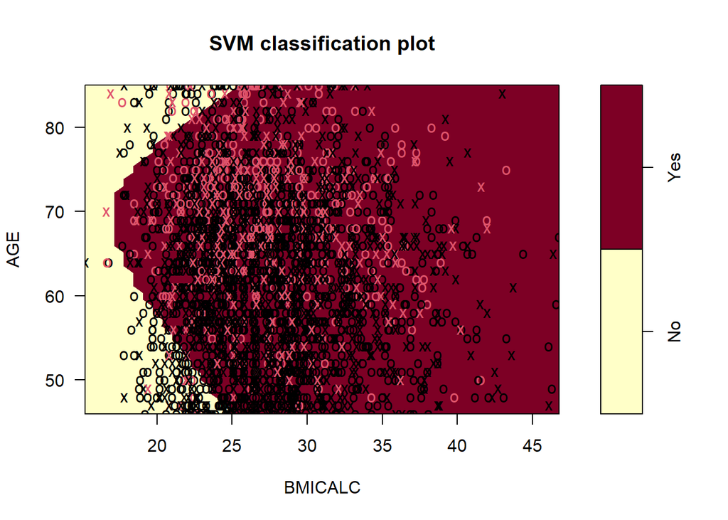

```r
plot(svm_poly_initial,nhis_data_clean, AGE ~ BMICALC)
```

```r
set.seed(1234)
nhis_tune_poly <- tune(svm, CANCEREV ~ AGE + SEX + POVERTY + BMICALC + ALCDAYSYR,data = nhis_train,kernel = "polynomial",ranges = list(cost = c(0.01, 0.1, 1, 10, 100),degree = c(2, 3, 4)))

summary(nhis_tune_poly)
```

```
##
## Parameter tuning of 'svm':
##
## - sampling method: 10-fold cross validation
##
## - best parameters:
##  cost degree
##  0.01      2
##
## - best performance: 0.202806
##
## - Detailed performance results:
##     cost degree     error dispersion
## 1  1e-02      2 0.2028060 0.02561436
## 2  1e-01      2 0.2028060 0.02561436
## 3  1e+00      2 0.2028060 0.02561436
## 4  1e+01      2 0.2028060 0.02561436
## 5  1e+02      2 0.2028060 0.02561436
## 6  1e-02      3 0.2028060 0.02561436
## 7  1e-01      3 0.2028060 0.02561436
## 8  1e+00      3 0.2028060 0.02561436
## 9  1e+01      3 0.2028060 0.02561436
## 10 1e+02      3 0.2028060 0.02561436
## 11 1e-02      4 0.2028060 0.02561436
## 12 1e-01      4 0.2048893 0.02726119
## 13 1e+00      4 0.2054101 0.03099770
## 14 1e+01      4 0.2064545 0.02931251
## 15 1e+02      4 0.2132363 0.02712268
```

```r
nhis_best_poly <- nhis_tune_poly$best.model
nhis_best_poly_pred <- predict(nhis_best_poly, newdata = nhis_test)
nhis_best_poly_conf <- confusionMatrix(nhis_best_poly_pred, nhis_test$CANCEREV)
nhis_best_poly_conf
```

```
## Confusion Matrix and Statistics
##
##           Reference
## Prediction  No Yes
##        No  667 156
##        Yes   0   0
##
##                Accuracy : 0.8104
##                  95% CI : (0.782, 0.8367)
##     No Information Rate : 0.8104
##     P-Value [Acc > NIR] : 0.5214
##
##                   Kappa : 0
##
##  Mcnemar's Test P-Value : <2e-16
##
##             Sensitivity : 1.0000
##             Specificity : 0.0000
##          Pos Pred Value : 0.8104
##          Neg Pred Value :    NaN
##              Prevalence : 0.8104
##          Detection Rate : 0.8104
##    Detection Prevalence : 1.0000
##       Balanced Accuracy : 0.5000
##
##        'Positive' Class : No
##
```

After tuning, the best Polynomial SVM model used a degree of 2 and a cost of 0.01. However, the tuned model still showed similar performance to the untuned one, with an overall accuracy of about 81%. The model predicted “No” for nearly all cases, resulting in a very high sensitivity (1.0) but very poor specificity (0.0). This suggests that tuning did not significantly improve classification of the “Yes” (cancer) cases, likely due to imbalance and overlap in the predictors.Even after tuning, the model struggled because the data had a lot of overlap between cancer and non-cancer cases.

combied results of all 3 models

```r
final_results <- data.frame(
  Model = c("Linear SVM", "Radial SVM", "Polynomial SVM"),
  Accuracy = c(0.810, 0.786, 0.807),
  Sensitivity = c(1.000, 0.943, 0.994),
  Specificity = c(0.000, 0.115, 0.006)
)
final_results
```

```
##            Model Accuracy Sensitivity Specificity
## 1     Linear SVM    0.810       1.000       0.000
## 2     Radial SVM    0.786       0.943       0.115
## 3 Polynomial SVM    0.807       0.994       0.006
```

Based on these results, none of the models performed particularly well at detecting “Yes” (cancer) cases. However, the Radial SVM showed the best balanced accuracy among all three models and might be preferred if detecting cancer cases was a critical goal, Improving the detection of “Yes” cases would likely require additional variables, better feature engineering, or methods specifically designed to handle imbalanced datasets, such as SMOTE but I didnt use because this is real world data and we cannot do changes on our own.

### Conclusion

Given these findings, I would recommend that policymakers focus on broad strategies-such as universal screening, health education, and making preventive care accessible to all older adults-rather than targeting only specific income or lifestyle groups. Since no single factor perfectly predicts cancer risk, improving early detection and prevention for everyone in higher-risk age groups is likely to be more effective than narrowing efforts to just a few high-risk subgroups.